# Still Exploring

## Preliminaries

In the last module, we saw how to build sub-tables and then plot data that shows us the general picture of who survived and who did not. In this module we will look at a slightly more sophisticated plotting mechanism called stacked-bars. We will also see that to use stacked-bars effectively, there is a bit more data wrangling we will need to do. First load in the titanic data and then we will continue exploring.

```python
%matplotlib inline

from csv import DictReader # helps with handling csv formatted data

from urllib2 import urlopen # helps with pulling data off the web

url = 'https://docs.google.com/spreadsheets/d/1z1ycUZjJpmMWB4gXbhwRQ9B_qa42CwzAQkf82mLibxI/pub?output=csv'

response = urlopen(url)

titanic_table = [row for row in DictReader(response)]
print(titanic_table[0])  # print the first row of the table - Mr. Braund
print(len(titanic_table))
```

```
{'Fare': '7.25', 'Name': 'Braund, Mr. Owen Harris', 'Embarked': 'S', 'Age': '22', 'Parch': '0', 'Pclass': '3', 'Sex': 'male', 'Survived': '0', 'SibSp': '1', 'PassengerId': '1', 'Ticket': 'A/5 21171', 'Cabin': ''}
891
```

## Age and its missing values

In a prior module we saw that there were 177 rows with a missing Age value. We did compute the mean age of those we do have values for at 29.7. I am going to build a new list with mean filling in missing values. To do this, I am going to use the ifelse-mapping concept we saw in module 5. I am still going to go through every row in the titanic table. But I have to make a decision on what value to copy to the new list. If an Age value exists, then just copy it. But if it is missing, then copy 29.7. You can read the code below as "Go ahead and copy the Age value across if it exists (actually, float it first given it is a string). Else, if the value is missing do the alternative of copying the value 29.7 (the mean) across.

```python
age_with_mean = [float(row['Age']) if row['Age'] != "" else 29.7 for row in titanic_table]
print(len(age_with_mean))  # 891 is what we expect - all passengers now have an age
```

```
891
```

Now let's plot the ages of passengers. I'll use 10 bins on the x-axis, i.e., divide the entire age range into 10 bins. Why 10 bins? It's a first guess. I'm going to view the `Age` column as numeric (also known as *continuous*) as opposed to categorical. If I had distinct categories (like with `Pclass` and `Embarked`), I'd use a bin per category. But given age is a continuos numerical range, I can play around with different bin numbers. I like 10 to start.

### Max and min of a list

Before getting to plotting, it is often useful to know the minimum and maximum value of a numerical column. Python gives us two functions to compute this, `min` and `max`. Let's take a look at the `age` column.

```python
print(min(age_with_mean))
print(max(age_with_mean))
```

```
0.42
80.0
```

Given that we are using 10 bins, we can expect each bin to hold a range of 8 values: 80/10 == 8. So our first bin will hold (roughly) 0-7, our second 8-15, etc. In essence, we are looking at ages in chunks of 8. If you increase the number of bins, you will get smaller chunks, e.g., 20 bins will give you bins of range 4.

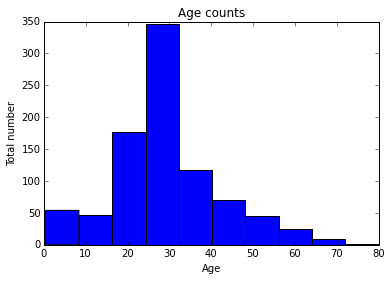

```python
import matplotlib.pyplot as plt

plt.hist(age_with_mean, 10)  # 10 bins to divide up age range into chunks of 8

plt.xlabel("Age")
plt.ylabel("Total number")
plt.title("Age counts")

plt.show()
```

Given a large number of passengers in the 16-31 age range, this looks like a promising place to explore. Keep in mind that 177 of the passengers in this range are those missing an age and had 29.7 assigned by us.

## Stacked bars

At this point, we could calculate the survival for all 10 bins, giving us 10 separate plots. I have a better way. What I'd like to see are the bins on the x-axis and a "stacked bar" on y-axis. A stacked-bar gives you 2 or more pieces of information in *one bar* by dividing the bar on percentages. Might be easiest to show you. I'll first break out 2 different lists: ages of those who survived and ages of those who perished.

```python
ages_survived = [float(row['Age']) if row['Age'] != '' else 29.7 for row in titanic_table if row['Survived'] == '1']
ages_perished = [float(row['Age']) if row['Age'] != '' else 29.7 for row in titanic_table if row['Survived'] == '0']
```

Another way to look at this is to build 2 sub-tables, survived_table and perished_table.

```python
survived_table = [row for row in titanic_table if row['Survived'] == '1']
perished_table = [row for row in titanic_table if row['Survived'] == '0']
```

Now pull the `Age` column out of each. Check to see that both approaches give same result. Choose the one that makes the most sense to you.

```python
ages_survived_v2 = [float(row['Age']) if row['Age'] != '' else 29.7 for row in survived_table]
ages_perished_v2 = [float(row['Age']) if row['Age'] != '' else 29.7 for row in perished_table]

print(ages_survived == ages_survived_v2)  # True
print(ages_perished == ages_perished_v2)  # True
```

```
True
True
```

Ok, here is the cool part. We can put both lists in a new list and give it to the `hist` function as `[ages_survived,ages_perished]`. Let's look at the plot first then discuss.

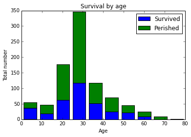

```python
plt.hist([ages_survived,ages_perished], 10, stacked=True, label=['Survived','Perished'])

plt.xlabel("Age")
plt.ylabel("Total number")
plt.title("Survival by age")

plt.legend()  # this is new - it uses the label values from the list above

plt.show()
```

Let's focus on the first bar on the left that has a blue component and a green component. How is that bar constructed? Here is what the `hist` function does:

1. For the blue part, `hist` counts the number of times the numbers 0-7 show up in `ages_survived`. That count gives the height of the blue piece.
2. For the green part, `hist` counts the number of times the numbers 0-7 show up in `ages_perished`. That count gives the height of the green piece.
3. Now stack them on top of each other and produce the first bar. The bar's height is the combination of the blue height and green height.

The information we get is the total count of passengers in age range 0-7 (height of whole bar). But we also see how that total count was divided by survived and perished (blue and green pieces).

Moving to the next bar, we are now looking at ranges 8-15. The `hist` function does the same. Count number of ages 8-15 in `ages_survived` (blue part) and `ages_perished` (green part). Stack them to get 2nd bar. Keep doing the same for all 10 bars.

I like this type of plot. The length of the entire bar gives you the total count for the bin. Then the colors divide it up between first and second list. We cleverly made the first list those who survived and second those who perished. And just to keep things straight, we added a legend to remind ourselves of the colors.

### How to use the plot

The plot above gives me useful information. It tells me what ages might be good candidates for prediction. For instance, the range 0-7 has a much larger blue piece (survived) than green (perished). It also tells me, by the total length of the bars, there are not than many passengers 7 and under. So even if I came up with a fabulous predictor for those ages 0-7, I would only cover roughly 7% of all the passengers; still have to worry about predictions for the other 93%. I'll keep that in mind as we move into building a predictor.

Note that I say `stacked=True`. This is a special argument to `hist` that tells it to stack the values in the 2 lists on top of each other. If I removed it, they would be shown side-by-side.

Again, we could clean the plot up by centering the age values on the bins and changing the colors of the bars, but I am going to go with what we have.

## Applying the same idea again

Let's see if we can come up with a general strategy for using stacked bars:

1. Find a column that you wish to explore.
2. Choose how to deal with empties.
3. Create a list of column values for those who survived. Fill in empties and convert to numbers.
4. Create a list of column values for those who perished. Fill in empties and convert to numbers.
5. At this point you have the 2 lists to give to `hist`.
6. Choose the number of bins that makes sense. If small set of categories, choose a bin per category.

Let's test these steps out. I'll choose `Pclass` as next column to explore (step 1). There are no empties (step 2). Below carries out steps 3 and 4.

```python
pclass_survived = [int(row['Pclass']) for row in titanic_table if row['Survived'] == '1']
pclass_perished = [int(row['Pclass']) for row in titanic_table if row['Survived'] == '0']
```

Almost ready to go (step 5). We have to choose number of bins. Given we have 3 categories, I am going to choose 3 bins (step 6). Other than that, I'll copy and paste from code above and change a few strings. I did add an `xticks` function to give me a little cleaner labeling on x-axis.

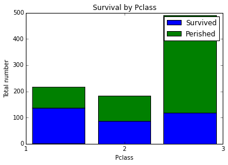

```python
plt.hist([pclass_survived,pclass_perished], 3, stacked=True, label=['Survived','Perished'])

plt.xlabel("Pclass")
plt.ylabel("Total number")
plt.title("Survival by Pclass")
plt.xticks([1,2,3])  # optional but useful
plt.legend()

plt.show()
```

From the last module, we already saw that class 3 had a large percentage of those who perished. Plot above helps me put all 3 classes into perspective. In particular, it looks like first class bucked the perished trend and had a higher rate of survival than table as whole. Second class also looks like it does better on survival than table as whole. Unfortunately, 3rd class has the unhelpful combination of holding most of the passengers and being close to overall perished rate. Suggests to me that for those in 3rd class, I am going to have to look at more details (e.g., age of those in 3rd class) to do better than overall rate.

## A column that is problematic - Embarked

The `Pclass` column is fortuitous in that its values are already converted to categoy numbers for us. All we have to do is convert the string form to int form. For tables we see in the future, this often will not be the case. The values in a column will be text strings. In these cases, we will have to convert the text to our own category numbers. A good example is the `Embarked` column. I can't use `int('C')` to convert someone who embarked in Cherbourg to an int. I'll get a Python error *unable to convert 'C' to int*.

If we are lucky, the column we focus on will only have 2 categories, e.g., `Sex`. In that case, I can use the ifelse style of mapping to convert one category to 0 and the other to 1. But the `Embarked` column has 3 values and they are all text. I will not be able to use an ifelse map to convert them.

We are going to have to write our own converter function. Gulp.

## Taking ownership of your functions

So far we have been users of functions that others have written. So someone wrote `len` and `int` and `float`. Big thanks to them (whoever them is) for doing that. Now it's time for us to add to the mix. Here is the general form of what I think we want for the `Embarked` column. First I'll set up some test rows with different values in the `Embarked` column:

```
row_c = {..., 'Embarked': 'C'}
row_s = {..., 'Embarked': 'S'}
row_q = {..., 'Embarked': 'Q'}
row_e = {..., 'Embarked': ''}
```

I want Python to give me a function, `e_converter`, that will give a number to each different value in `Embarked`. If I give it a row with `Embarked` equal to 'C', I want it to give me a 1. If I give it a row with `Embarked` equal to 'S', I want it to give me a 2. Similar for 'Q' and '' (empties). If I execute the code below, I'll see 1, 2, 3 and 0 printed.

```
print( e_converter( row_c ) )  # 1
print( e_converter( row_s ) )  # 2
print( e_converter( row_q ) )  # 3
print( e_converter( row_e ) )  # 0
```

My choice of assigning numbers to categories is arbitrary. Only contraint is that each category (4 of them) has a unique number. You can decide what category goes with what number if you don't like mine.

Once Python give us this cool function, we can use it in our general stacked-bar strategy to produce 2 lists:

```
embarked_survived = [e_converter(row) for row in titanic_table if row['Survived'] == '1']
embarked_perished = [e_converter(row) for row in titanic_table if row['Survived'] == '0']
```

and then set up our hist function:

```
plt.hist([embarked_survived,embarked_perished], 4, stacked=True, label=['Survived','Perished'])

plt.xlabel("Embarked (C-1, S-2, Q-3, E-0)")
plt.ylabel("Total number")
plt.title("Survival by Embarcation")
plt.xticks([1,2,3,4])  # optional but useful
plt.legend()

plt.show()
```

I have some bad news. Python is not going to give us the `e_converter` function. In fact, when I went to the Python gurus to ask for it, they responded somewhat gruffly "we are busy, write it yourself - we give you all the tools to do so."

Let's look at what Python does give us to write the `e_converter` function ourselves.

## A text-converter template

I'll show you how to write the `e_converter` function and do so in a way that will make the same style usable for other text columns you might run into. First I'll give you the code then discuss.

```python
def e_converter(row):
    embarcation = row['Embarked']
    if embarcation == 'C':
        return 1
    if embarcation == 'S':
        return 2
    if embarcation == 'Q':
        return 3
    if embarcation == '':
        return 0
    raise ValueError('Unknown embarcation value: ' + embarcation)
```

Let's try it out to make sure it does what we want. I am not going to copy over entire Titanic rows - I am just interested in the `Embarked` field at this point.

```python
# define some small test dictionaries (rows) that represent each category
row_c = {'Embarked': 'C'}
row_s = {'Embarked': 'S'}
row_q = {'Embarked': 'Q'}
row_e = {'Embarked': ''}

print( e_converter( row_c ) )  # 1
print( e_converter( row_s ) )  # 2
print( e_converter( row_q ) )  # 3
print( e_converter( row_e ) )  # 0
```

```
1
2
3
0
```

Ok, let's go over this new code line by line.

```
def e_converter(row):
    embarcation = row['Embarked']  # assignment statement
    if embarcation == 'C':  # case 1
        return 1
    if embarcation == 'S':  # case 2
        return 2
    if embarcation == 'Q':  # case 3
        return 3
    if embarcation == '':  # case 4
        return 0
    raise ValueError('Unknown embarcation value: ' + embarcation)
```

- The `def` stands for *define*. You use it to define your own function. You can name your function anything you like. I chose `e_converter` for *embarcation converter*. Always use `row` as an argument. Don't forget the colon at the end of the line.
- The second line is just a plain old assignment statement. It is assigning the variable `embarcation` to the value in the `Embarked` field of `row`. So this variable should contain either the string 'C', 'S', 'Q', or ''.
- The next set of statements look a lot alike. They make up 4 cases. Each case checks one of the categories. If there is a match, `e_converter` returns immediately with an answer (0-3 depending on which case matched).
- The final statement is for your protection. You will execute the `raise` function if none of the 4 cases match. How can this be, you ask. You have all 4 cases covered. There are no other cases in the `Embarked` column. You will never get to the `raise` statement because one of the return statements will happen.

The more you program, the more you realize that "never" never happens. Trust me. You want to know if the never happens. You can make up the message you want the user (you) to see. I am using this: `'Unknown embarcation value: ' + embarcation`. The `+` conjoins the 2 strings together, allowing me to print a message (on left) and the value that somehow slipped through my cases (on right).

Let's test out the `raise` statement by using 'X' as an embarcation point. This should never happen. But just in case someone messed up when the table was built, we will see how `raise` catches these type of errors.

```python
row_bug = {'Embarked': 'X'}  # X was not an embarcation site so raise an error

x_conversion = e_converter( row_bug )   # error
```

```
---------------------------------------------------------------------------
ValueError                                Traceback (most recent call last)
<ipython-input-16-ed8d7ba6fcc8> in <module>()
      1 row_bug = {'Embarked': 'X'}  # X was not an embarcation site so raise an error
      2
----> 3 x_conversion = e_converter( row_bug )   # error

<ipython-input-14-786cfa3f5c9c> in e_converter(row)
      9     if embarcation == '':
     10         return 0
---> 11     raise ValueError('Unknown embarcation value: ' + embarcation)

ValueError: Unknown embarcation value: X
```

That is your `raise` statement causing the error. You've gone from being on the receiving end of error messages to now delivering them. Nice reversal of fortunes.

Ok, let's put your function to use. We need 2 lists of ints to use stacked-bars and we can use `e_converter` to get them.

**Important note:** I am not filling in the 2 empties but letting them be their own value 0. So they are the first bar on the left.

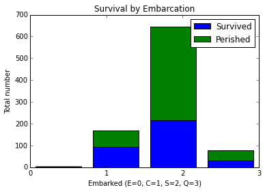

```python
embarked_survived = [e_converter(row) for row in titanic_table if row['Survived'] == '1']
embarked_perished = [e_converter(row) for row in titanic_table if row['Survived'] == '0']

plt.hist([embarked_survived,embarked_perished], 4, stacked=True, label=['Survived','Perished'])

plt.xlabel("Embarked (E=0, C=1, S=2, Q=3)")
plt.ylabel("Total number")
plt.title("Survival by Embarcation")
plt.xticks([0,1,2,3])  # optional but useful
plt.legend()

plt.show()
```

Way I read it, most passengers embarked in Southhampton and the survival rate for them roughly mirrors overall rate. The Cherbourg bar looks like it has a higher survival rate than overall rate. On the downside, many fewer passengers in that category. Queenstown is a double whammy - mirrors overall rate and not a lot of passengers. The empties bar is so small that my next step would be to compute the mode of the column and just fill in the 2 empty values with the mode. This would reduce our categories to 3. We would have to rewrite the `e_converter` function to remove the check for ''.

## One last example

Now that we have a strategy for writing our own converters, let's try it out on another column, `Name`. This certainly is a text column. But you could reasonably argue that there are no categories to pull out in the column. Every name is unique. But I have a theory, which is that salutation matters in terms of survival rate. I am going to come up with the following categories: 'Mr.' - 1, 'Mrs.' - 2, 'Miss.' - 3, 'Master.' - 4, other - 5. Then check how each does for survival.

I am going to copy the e_converter from above and make the following changes:

1. change the function name to `s_converter` for *salutation converter*.
2. change the variable to `name` and use `Name` field
3. change the cases to look for the salutations within `name`.
4. I'll comment out the `raise` statement - it is not needed because of "other" case

For step 3, I glibly said I would look for salutations within the name string. How? Turns out Python gives us a simple way to check if one string is contained within another string. It is the `in` operator, which returns True or False. I'll set the variable name to one of the name strings in our table (first passenger) and then see how the `in` operator does its job.

```python
passenger1 = titanic_table[0]

name = passenger1['Name']  # 'Braund, Mr. Owen Harris'

print(name)
print('Mr.' in name)  # True
print('Mrs.' in name)  # False
print('Master.' in name)  # False
```

```
Braund, Mr. Owen Harris
True
False
False
```

Ok, I think we have what we need to modify `e_converter` to get our new converter function to categorize the `Name` column around salutations.

```python
def s_converter(row):
    name = row['Name']
    if 'Mr.' in name:
        return 1
    if 'Mrs.' in name:
        return 2
    if 'Miss.' in name:
        return 3
    if 'Master.' in name:
        return 4
    return 5  # other case if no case above matches
    #raise ValueError('Could not find salutation in name: ' + name)
```

Let's try it out. I am using 5 bins to go with my 5 categories.

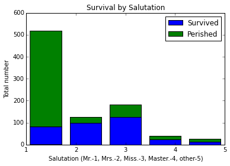

```python
salutation_survived = [s_converter(row) for row in titanic_table if row['Survived'] == '1']
salutation_perished = [s_converter(row) for row in titanic_table if row['Survived'] == '0']

plt.hist([salutation_survived,salutation_perished], 5, stacked=True, label=['Survived','Perished'])

plt.xlabel("Salutation (Mr.-1, Mrs.-2, Miss.-3, Master.-4, other-5)")
plt.ylabel("Total number")
plt.title("Survival by Salutation")
plt.xticks([1,2,3,4,5])  # optional but useful
plt.legend()

plt.show()
```

Does this help us in terms of prediction? Probably not. It follows the general trend of male versus female survival. The main take-away is that there will be other tables you look at with text fields that might harbor interesting data. You can use the general style of e_converter and s_converter to get those columns in shape for plotting, i.e., convert categorical text data to category numbers. And we will also see that the same converters will be useful when we move to actually building predictors.

## Next up

We could certainly do more exploration. We have not touched the columns Parch or Sibsp, nor the Fare column. They may hold powerful predictors. Maybe everyone who had a Parch value of 2 survived. I don't think so but we have not explored it to find out. I think we have enough now to get to early predictions so we will go with what we have in the next module.

## Epilog: What plot types did we miss?

Most of them! If you love playing with visuals, there are many features of matplotlib and related Python packages that will let you go crazy. Google around and you can find them. But just as a taste, below is a sampler.

### Incremental complexity

We have been progressing through the plots we are using by starting simple then adding more features. We started with simple `hist`. Then added descriptions of the axis and a title. With stacked bars, we added yet more features. The path you follow to get to different plots will be more of the same. You will have to define new features that are particular to that plot type but reuse other pieces that cut across all plots. The pie chart is a good example. It is slightly more complex in the number of features you have to set up, but should look familiar. Here is the code for a simple pie-chart. Notice that you only have to define the first two variables: the list of labels to go on the pie pieces and the list of sizes of the pie pieces. The reamining code can be used unchanged until you want to explore fancier graphical options.

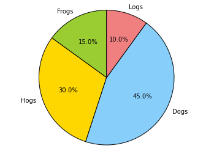

```python
slice_labels = ['Frogs', 'Hogs', 'Dogs', 'Logs']
slice_sizes = [15, 30, 45, 10]
slice_colors = ['yellowgreen', 'gold', 'lightskyblue', 'lightcoral']

plt.pie(slice_sizes,  labels=slice_labels, colors=slice_colors,
        autopct='%1.1f%%', startangle=90)

plt.axis('equal')  # Set aspect ratio to be equal to get a circle.
plt.show()
```

A pie chart with fancier options set:

[figure not shown]

The heat map and GIS style plots below will take some work. The good news is that lots of people get stuck trying to use various plots and they ask questions online. And experts answer! So a combination of going through tutorials and looking at questions on something like stackoverflow.com is a good approach.

[figure not shown]